# Reproducible Research

03 May 2017

## Kyle who?

- MS in Biostatistics from OHSU in June 2014
- 2016 – Now: Statistician at OHSU Department OB/GYN
- 2014 – 2016: Statistician at OHSU Department of Surgery
- 2014 - Now: Statistician with the Biostatistics & Design Program
- 2013 – 2014: Data manager at the VA
- 2004 – 2013: Data manager in industry

## Why I act this way

- I've been writing code since I was 8; I see all this through the eyes of a programmer.
- I'm deeply committed to R.
- I'm cautiously optimisitc about the Hadley Wickham/tidyverse/RStudio movement.
- It's all about literate programming.

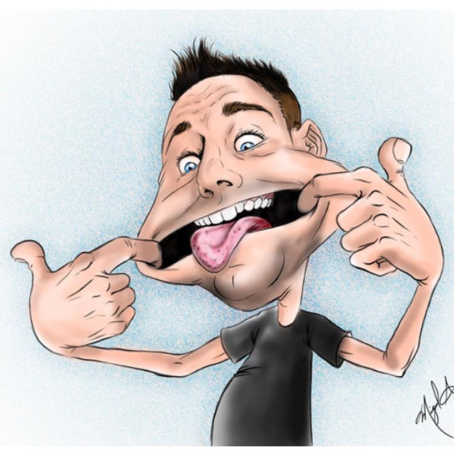

## (with applications in R)

This talk will focus on applications in R.

- I think implementations in SAS and Stata are clunky and immature.
- SPSS, as far as I can tell, isn't even really trying.
- Also, because R is just how I roll.

## What is research?

What is not resarch?

## Things that are not research

- Journal article
- Talk at a conference
- Poster
- Slide deck
- Book
- Web site

These things are not research; they are advertising for research. Research is "the full software environment, code, and data that produced the results."

(Claerbout 1992)

## Gold standard: Replicability

## Gold standard: Replicability

- The research includes enough stuff that a different researcher can follow the same procedures in a new sample and come up with the same results.
- Hard to do if the original study used the whole population or if there isn't funding to replicate the results.
- Perhaps journals are culpable here because "statistically significant, novel, and theoretically tidy results are published more easily than null, replication, or perplexing results" (Miguel et al).

## Next-best thing: Reproducibility

When replicability is not feasible, reproducibility is a minimum standard for judging scientific claims.

(Peng 2011)

The research includes enough stuff that a different researcher can follow the same procedures in the same sample and come up with the same results.

## Why is reproducibility important?

- Reproducible does not mean results aren't wrong.
- Reproducible does not mean results are credible.
- Reproducibility does not mean results are not sensitive to methods.
- But it exposes these things so peers can spot them and improve scientific consensus.

## Why is reproducibility important?

- If you know somebody else might look, your code might magically become more organized
- Improves collaboration
- Who is your most important collaborator?
- Revise and resubmit. Make it easier for Future You.

You could get hit by a bus.

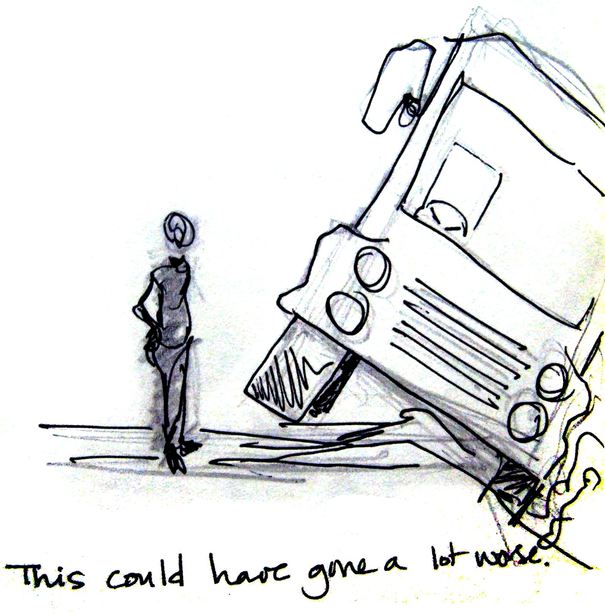

## Traditional (non-reproducible) workflow

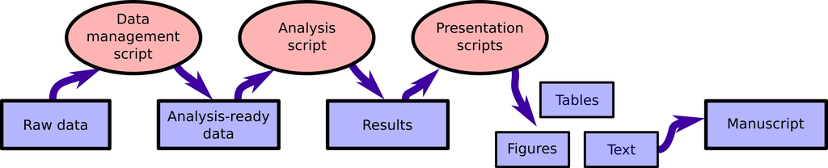

## Reproducible workflow

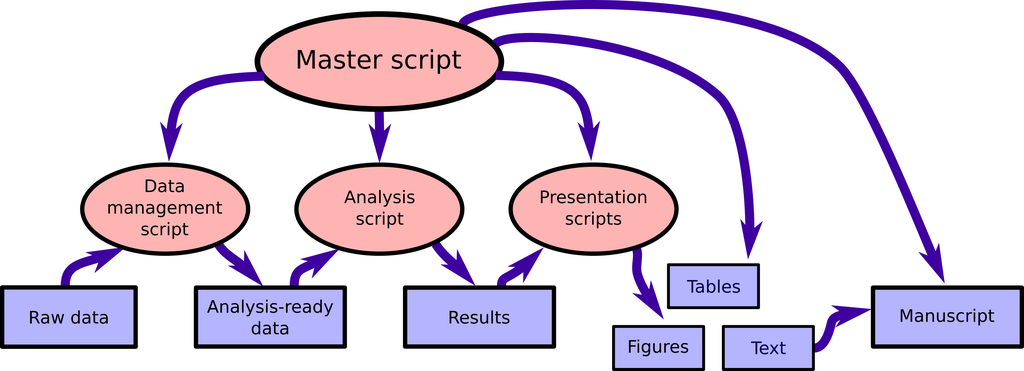

## Minimum components of a reproducible project

- Data
- Code
- Software (including versions)
- Presentation (manuscript, slide deck, or whatever)
- Documentation that explains how all the pieces are connected

## Barebones tools

- Data:
  - X Drive
  - Data dictionary
    - Names of data files and what they contain
    - Columns used in analysis
    - Names and definitions of data columns
    - Value labels and coding conventions for categorical variables

## Barebones tools

- Code:
  - R
- Software:
  - R
  - R packages
  - Code comments or Word document to keep track of versions

## Barebones tools

- Presentation:
  - MS Word
  - MS Powerpoint
  - Whatever
- Documentation:
  - MS Word
  - Code comments

## Tools that integrate reproducibility into workflow

- Data:
  - Git/GitHub
  - Make files and R make-like files
  - Data dictionary
- Code:
  - RStudio (is anybody using R without RStudio?)
  - tidyverse
  - Master script

## Tools that integrate reproducibility into workflow

- Software:
  - R
  - packrat
- Presentation and documentation:
  - knitr
  - RMarkdown
  - LaTeX
  - Git/GitHub

## A literate document

```r
coxAids <- coxph(Surv(Time,death) ~ drug + gender + CD4 + AZT,
                 data=aids.id)
```

We examined survival time among 467 AIDS patients using a Cox proportional hazards model , adjusting for drug treatment group , gender , baseline CD4 lymphocyte count , and history of Zidovudine (AZT) tolerance or failure.

Significant predictors included baseline CD4 lymphocyte count (HR: 0.844, 95% CI: 0.807, 0.882) and history of AZT failure (HR: 1.499, 95% CI: 1.116, 2.014).

## A literate document

```{r}

coxAids <- coxph(Surv(Time,death) ~ drug + gender + CD4 + AZT, data=aids.id)

```

We examined survival time among ` r length(aids.id$patient)` AIDS patients using a Cox proportional hazards model, adjusting for drug treatment group, gender, baseline CD4 lymphocyte count, and history of Zidovudine (AZT) tolerance or failure.

Significant predictors included baseline CD4 lymphocyte count (HR: ` r round(exp(coef(coxAids)[3]), 3)` , 95\% CI: ` r round(exp(confint(coxAids)),3)[3,]` ) and history of AZT failure (HR: ` r round(exp(coef(coxAids )[4]) , 3)` , 95\% CI: ` r round(exp(confint(coxAids)),3)[4,]` ).

## A literate document

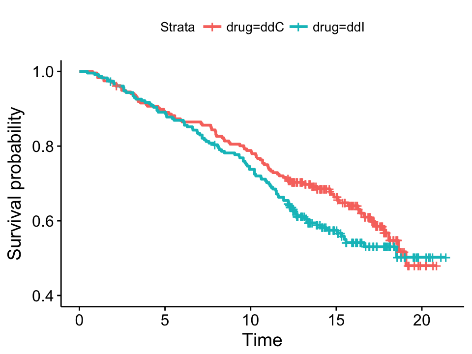

```r
fit <- survfit(Surv(Time, death) ~ drug, data = aids.id)
ggsurvplot(fit, data = aids.id, ylim = c(0.4, 1))
```

## A literate document

```{r}

fit <- survfit(Surv(Time, death) ~ drug, data = aids.id)

ggsurvplot(fit, ylim = c(0.4, 1))

```

## File management

- Working folders
- Relative paths
- Getwd(), and setwd()
- RStudio projects

## Git/GitHub

## Git on Exacloud

Initialize Git in your local directory:

```
$ cd foo
$ git init
```

Initialize a repository on Exacloud:

```
$ mkdir foo.git
$ cd foo.git
$ git init --bare
```

## Git on Exacloud

Tell your local Git where the remote repository is:

```
$ git remote add origin <username>@exacloud.ohsu.edu:<repo-name>.git
$ git remote -v
```

Write your code locally. Save changes. Add new files to Git:

```
$ git add foobar.R
```

## Git on Exacloud

Commit your changes locally and add a comment to mark your spot:

```
$ git commit -m "Added foobar.R"
```

Push your changes to the remote repository on Exacloud:

```
$ git push origin master
```

## packrat

Initialize packrat for your R project:

```
> library(packrat)
> packrat::init("~/projects/foobar")
```

Load your packages per usual routine:

```
> install.packages("foo")
> library(foo)
```

Save a snapshot:

```
> snapsnot()
```

Details here: https://rstudio.github.io/packrat/

## Resources

- Gandrud C. *Reproducible Research with R and RStudio*. 2nd ed. 2015; CRC Press, Boca Raton, FL.
- Xie Y. *Dynamic Documents with R and knitr*. 2nd ed. 2015; CRC Press, Boca Raton, FL.
- Grolemond G, Wickham H. *R for Data Science*. 2017; O'Reilly Media, Sebastopol, California.
- Ben Chan's analytic workflow for using Git on OHSU's Exacloud: https://github.com/benjamin-chan/workflow

## Thanks

I borrowed the concept for the workflow figures from Ben Chan, Stephanie Renfro, and Thomas Meath at the Center for Health Systems Effectiveness (CHSE). They gave a talk on reproducible research with knitr on July 22, 2015.